# Results

Loong Kuan

16 September 2016

## Original Data of 2 Dates

Load the satellite data set on the day *2013-05-05* and *2013-11-29*.

Data from *2013-05-05*.

```
##       band7    band5    band6 brightness    band3      NDWI    band4     NDVI
## 1  73.04878 366.5366 137.4878   408.9594 69.14634 -454.4399 47.07317 772.3788
## 2 102.95122 227.9756 161.4878   313.8552 61.29268 -170.7164 63.65854 563.4357
## 3 114.53658 219.8049 172.7073   319.6633 60.68293 -119.9900 69.48781 519.6021
## 4  97.36585 320.7073 158.0976   382.1191 60.90244 -339.6159 54.58537 709.1051
## 5  72.09757 433.5122 140.7561   468.4094 59.09756 -509.7898 37.02439 842.6291
##      band1    band2 id_class
## 1 26.02439 31.39024    maize
## 2 28.43902 35.17073    maize
## 3 30.82927 38.24390    maize
## 4 28.43902 34.48780    maize
## 5 26.02439 30.39024    maize
```

Data from *2013-11-29*.

```
##       band7    band5    band6 brightness    band3      NDWI    band4     NDVI
## 1  75.39024 408.2927 144.9024   451.2738 76.17073 -476.1254 50.58537 779.5259
## 2 116.60976 290.8049 184.9024   383.8199 75.34146 -222.6210 79.26829 571.6074
## 3 140.29268 258.4390 206.6585   384.4472 77.46342 -111.3325 92.90243 471.1559
## 4 114.92683 354.6585 178.7805   428.3625 72.21951 -329.7060 66.68293 683.4732
## 5  76.78049 458.0976 145.0488   494.1166 63.78049 -519.0262 38.19512 846.0782
##      band1    band2 id_class
## 1 27.19512 34.12195    maize
## 2 33.51220 43.36585    maize
## 3 38.63415 49.95122    maize
## 4 33.51220 41.90244    maize
## 5 27.19512 33.12195    maize
```

Histogram of the data by attributes.

```
## [1] "Plots Obtained"
```

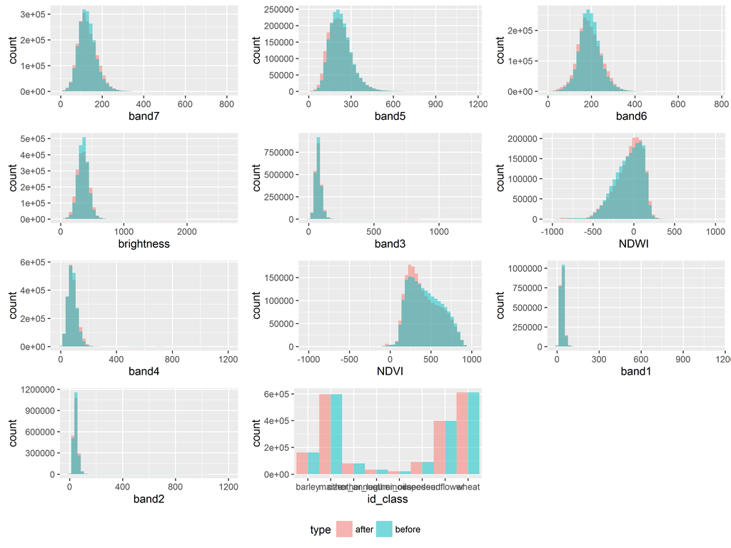

## Drift Results

The raw data of the results will be provided at the end of this document.

### Covariate Drift

The following is the results for a test of 1 Attribute. We can verify the correctness of the results by comparing them to the histograms of the attributes above.

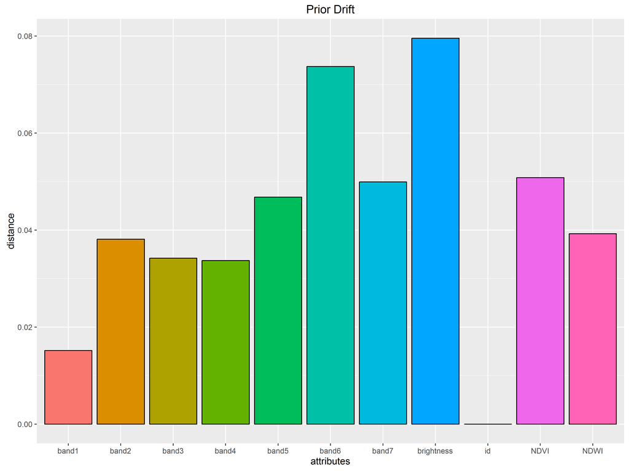

The following is the covariate results for 2 Attributes. This plot is just an exercise on how results from larger amounts of attributes might be visualised.

The plot is made by first constructing a “distance matrix” where the distance obtained for each pair of attribute is represneted.

```
##             [,1]       [,2]       [,3]       [,4]       [,5]       [,6]
##  [1,] 0.00000000 0.03891159 0.04238302 0.04436547 0.06389632 0.14215726
##  [2,] 0.03891159 0.00000000 0.10406747 0.04583436 0.14758604 0.07401491
##  [3,] 0.04238302 0.05203373 0.00000000 0.05176214 0.08354564 0.13868032
##  [4,] 0.04436547 0.04583436 0.10352429 0.00000000 0.07697077 0.06952289
##  [5,] 0.06389632 0.14758604 0.08354564 0.15394154 0.00000000 0.04713709
##  [6,] 0.14215726 0.07401491 0.06934016 0.06952289 0.04713709 0.00000000
##  [7,] 0.10433755 0.06411570 0.13338005 0.13030070 0.15428692 0.09931139
##  [8,] 0.12329761 0.07012983 0.07329804 0.13547446 0.07764798 0.05609954
##  [9,] 0.12119618 0.13477866 0.06159057 0.12489803 0.08424495 0.07193607
## [10,] 0.07669617 0.15301482 0.08034832 0.07825341 0.08914009 0.17389558
## [11,] 0.16062535 0.16114543 0.08143267 0.15918859 0.08280718 0.08226802
##             [,7]       [,8]       [,9]      [,10]      [,11]
##  [1,] 0.10433755 0.06164880 0.12119618 0.15339233 0.16062535
##  [2,] 0.06411570 0.14025965 0.13477866 0.15301482 0.08057272
##  [3,] 0.06669003 0.14659607 0.12318114 0.16069663 0.08143267
##  [4,] 0.13030070 0.06773723 0.12489803 0.07825341 0.15918859
##  [5,] 0.15428692 0.07764798 0.16848990 0.17828017 0.16561436
##  [6,] 0.09931139 0.11219909 0.14387214 0.08694779 0.16453604
##  [7,] 0.00000000 0.05399058 0.07611835 0.16444567 0.08127654
##  [8,] 0.05399058 0.00000000 0.15252686 0.08014701 0.16340048
##  [9,] 0.07611835 0.07626343 0.00000000 0.16391956 0.17007425
## [10,] 0.16444567 0.16029402 0.08195978 0.00000000 0.08597840
## [11,] 0.08127654 0.16340048 0.17007425 0.17195680 0.00000000
```

This matrix is then plotted using Multidimensional Scaling to visualise the distances in the matrix. The final plot will then plot attributes that have a higher dirft together further apart.

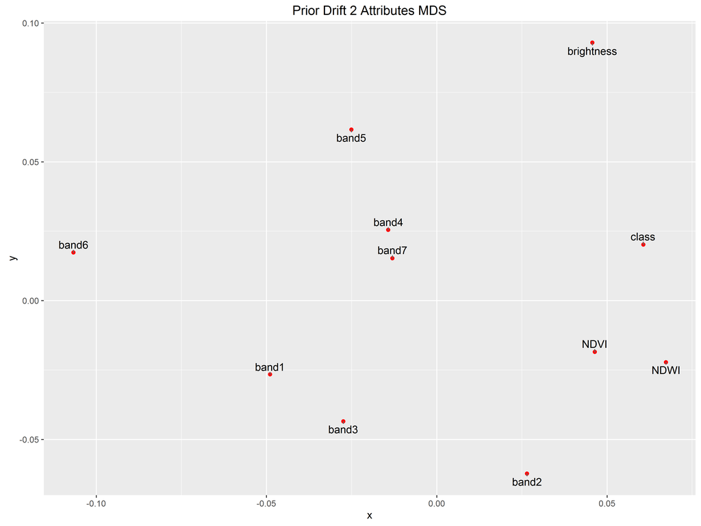

We can also plot the distance matrix as a heatmap to directly view the results. However this method only works with 2 attribute tests.

[interactive chart not shown]

Here is a heatmap for 3 attributes that contains the attribute with the highest variance in difference.

[interactive chart not shown]

### Conditioned Covaraites (Single Attributes)

[interactive chart not shown]

### Conditioned Covaraites (Pair Attributes)

```
## [1] "Plots obtained"
```

[interactive chart not shown]

### Posterior (1 Attribute)

[interactive chart not shown]

## Raw Data

https://github.com/LeeLoongKuan/DriftMapper/tree/master/data_out/martvard

## Raw Plots

https://github.com/LeeLoongKuan/DriftMapper/tree/master/DataAnalysisR/Plots